# FRE6971_FinalProject_DenizKural

### Signal 2

b. AR(1) model fitted to z(t,$\lambda$ = 0.05) (Signal 2)

```python
#Signal 2

c2_2y3y5y=AR1_EMA(c1,0.05,10)
c2_3y4y5y=AR1_EMA(c2,0.05,10)
c2_2y3y4y=AR1_EMA(c3,0.05,10)
c2_2y4y5y=AR1_EMA(c4,0.05,10)
```

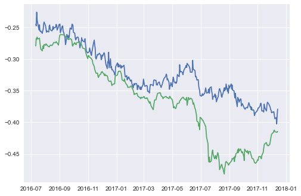

```python
plt.plot(c2_2y3y5y)
plt.show()
```

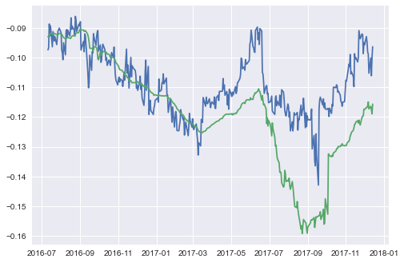

```python
plt.plot(c2_3y4y5y)
plt.show()
```

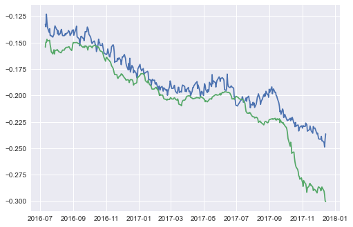

```python
plt.plot(c2_2y3y4y)
plt.show()
```

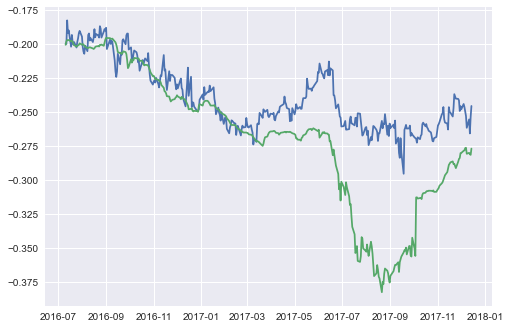

```python
plt.plot(c2_2y4y5y)
plt.show()
```

### Signal 3

c. AR(1) model fitted to z(t,$\lambda$ = 0.1) (Signal 3)

```python
#Signal 3

c3_2y3y5y=AR1_EMA(c1,0.1,10)
c3_3y4y5y=AR1_EMA(c2,0.1,10)
c3_2y3y4y=AR1_EMA(c3,0.1,10)
c3_2y4y5y=AR1_EMA(c4,0.1,10)
```

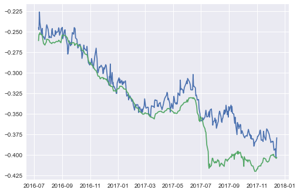

```python
plt.plot(c3_2y3y5y)
plt.show()
```

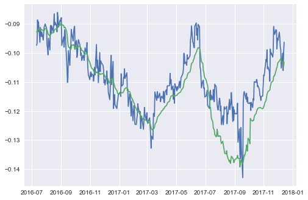

```python
plt.plot(c3_3y4y5y)
plt.show()
```

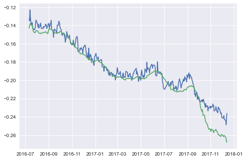

```python
plt.plot(c3_2y3y4y)
plt.show()
```

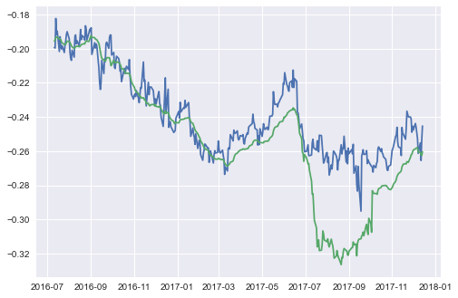

```python
plt.plot(c3_2y4y5y)
plt.show()
```

#### Signal 4 Optimization for Sample C

```python
#Initial value for lambda vector = [0.5,0.5,0.5]
lamda0=[0.5,0.5,0.5]
#For butterfly 1:
optim_model_c1 = optimizer(lamda0,c1)
optim_c1 = optim_model_c1.fit(lamda0)
#For butterfly 2:
optim_model_c2 = optimizer(lamda0,c2)
optim_c2 = optim_model_c2.fit(lamda0)
#For butterfly 3:
optim_model_c3 = optimizer(lamda0,c3)
optim_c3 = optim_model_c3.fit(lamda0)
#For butterfly 4:
optim_model_c4 = optimizer(lamda0,c4)
optim_c4 = optim_model_c4.fit(lamda0)
```

```python
print("The value for optimal \u03BB of [2y,3y,5y]  is " ,optim_c1.x)
print("The cost of the optimal \u03BB solution  is %.4f" %optim_c1.cost)

print("The value for optimal \u03BB of [3y,4y,5y] is " ,optim_c2.x)
print("The cost of the optimal \u03BB solution  is %.4f" %optim_c2.cost)

print("The value for optimal \u03BB of [2y,3y,4y] is  " ,optim_c3.x)
print("The cost of the optimal \u03BB solution  is %.4f" %optim_c3.cost)

print("The value for optimal \u03BB of [2y,4y,5y] is " ,optim_c4.x)
print("The cost of the optimal \u03BB solution  is %.4f" %optim_c4.cost)
```

```
The value for optimal λ of [2y,3y,5y]  is  [0.41738619 0.36439461 0.39586463]
The cost of the optimal λ solution  is 0.0001
The value for optimal λ of [3y,4y,5y] is  [0.27100699 0.35144935 0.60546296]
The cost of the optimal λ solution  is 0.0000
The value for optimal λ of [2y,3y,4y] is   [0.39342451 0.40734661 0.42923143]
The cost of the optimal λ solution  is 0.0000
The value for optimal λ of [2y,4y,5y] is  [0.45765815 0.28254301 0.38036075]
The cost of the optimal λ solution  is 0.0001
```

##### Signal 4 Results and Equation

Signal 4= Signal 1 x optimized_weight1 +Signal 2 x optimized_weight2+Signal 3 x optimized_weight3

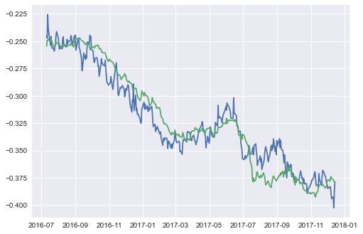

```python
s4_c1 = optimizer(optim_c1.x,c1)
predict=s4_c1.residuals(optim_c1.x)
plt.plot(s4_c1.s4)
```

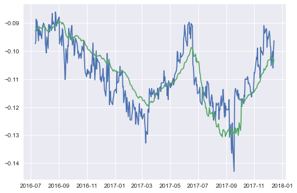

```python
s4_c2 = optimizer(optim_c2.x,c2)
predict=s4_c2.residuals(optim_c2.x)
plt.plot(s4_c2.s4)
```

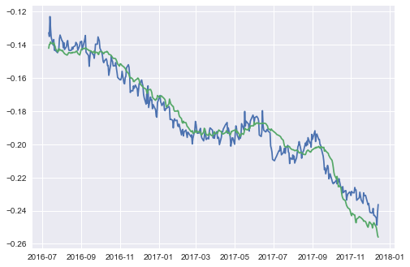

```python
s4_c3 = optimizer(optim_c3.x,c3)
predict=s4_c3.residuals(optim_c3.x)
plt.plot(s4_c3.s4)
```

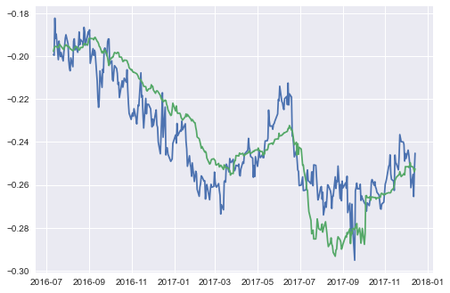

```python
s4_c4 = optimizer(optim_c4.x,c4)
predict=s4_c4.residuals(optim_c4.x)
plt.plot(s4_c4.s4)
```

```python
#Sample(C) Analysis for all range

#RMSE Error Check for Signals 1-4 from Sample C

print("Results for Signal 1 and Butterfly 1: [2y,3y,5y] ")
RMSE(c1_2y3y5y[:-10])
print("Results for Signal 1 and Butterfly 2 : [3y,4y,5y] ")
RMSE(c1_3y4y5y[:-10])
print("Results for Signal 1 and Butterfly 3: [2y,3y,4y] ")
RMSE(c1_2y3y4y[:-10])
print("Results for Signal 1 and Butterfly 4: [2y,4y,5y] ")
RMSE(c1_2y4y5y[:-10])

print()


print("Results for Signal 2 and Butterfly 1: [2y,3y,5y] ")
RMSE(c2_2y3y5y[:-10])
print("Results for Signal 2 and Butterfly 2 : [3y,4y,5y] ")
RMSE(c2_3y4y5y[:-10])
print("Results for Signal 2 and Butterfly 3: [2y,3y,4y] ")
RMSE(c2_2y3y4y[:-10])
print("Results for Signal 2 and Butterfly 4: [2y,4y,5y] ")
RMSE(c2_2y4y5y[:-10])

print()

print("Results for Signal 3 and Butterfly 1: [2y,3y,5y] ")
RMSE(c3_2y3y5y[:-10])
print("Results for Signal 3 and Butterfly 2 : [3y,4y,5y] ")
RMSE(c3_3y4y5y[:-10])
print("Results for Signal 3 and Butterfly 3: [2y,3y,4y] ")
RMSE(c3_2y3y4y[:-10])
print("Results for Signal 3 and Butterfly 4: [2y,4y,5y] ")
RMSE(c3_2y4y5y[:-10])

print()

print("Results for Signal 4 and Butterfly 1: [2y,3y,5y] ")
RMSE(s4_c1.s4[:-10])
print("Results for Signal 4 and Butterfly 2 : [3y,4y,5y] ")
RMSE(s4_c2.s4[:-10])
print("Results for Signal 4 and Butterfly 3: [2y,3y,4y] ")
RMSE(s4_c3.s4[:-10])
print("Results for Signal 4 and Butterfly 4: [2y,4y,5y] ")
RMSE(s4_c4.s4[:-10])
```

```
Results for Signal 1 and Butterfly 1: [2y,3y,5y]
RMSE: 0.015524132310390843
Results for Signal 1 and Butterfly 2 : [3y,4y,5y]
RMSE: 0.009651170935930866
Results for Signal 1 and Butterfly 3: [2y,3y,4y]
RMSE: 0.009733837297377555
Results for Signal 1 and Butterfly 4: [2y,4y,5y]
RMSE: 0.014693399057032309

Results for Signal 2 and Butterfly 1: [2y,3y,5y]
RMSE: 0.0538332717388518
Results for Signal 2 and Butterfly 2 : [3y,4y,5y]
RMSE: 0.015661767849746513
Results for Signal 2 and Butterfly 3: [2y,3y,4y]
RMSE: 0.02016153911175315
Results for Signal 2 and Butterfly 4: [2y,4y,5y]
RMSE: 0.044748340561428235

Results for Signal 3 and Butterfly 1: [2y,3y,5y]
RMSE: 0.025415309510076454
Results for Signal 3 and Butterfly 2 : [3y,4y,5y]
RMSE: 0.0077925255715024155
Results for Signal 3 and Butterfly 3: [2y,3y,4y]
RMSE: 0.00928905246300105
Results for Signal 3 and Butterfly 4: [2y,4y,5y]
RMSE: 0.02300776576417959

Results for Signal 4 and Butterfly 1: [2y,3y,5y]
RMSE: 0.013631409054232702
Results for Signal 4 and Butterfly 2 : [3y,4y,5y]
RMSE: 0.006875650695305276
Results for Signal 4 and Butterfly 3: [2y,3y,4y]
RMSE: 0.006846806961277784
Results for Signal 4 and Butterfly 4: [2y,4y,5y]
RMSE: 0.013802761785049631
```

#### Results Analysis:

As we see from the above, all RMSE values are lower than 0.1 which shows accurate prediction model.

Also, another important result is that the RMSE for the training and the test sets should be very similar if we have built a good model. So, when we compare the RMSE results for all signals, we can observe that we built a good model.

##### Signal 1 Distrubution Plots

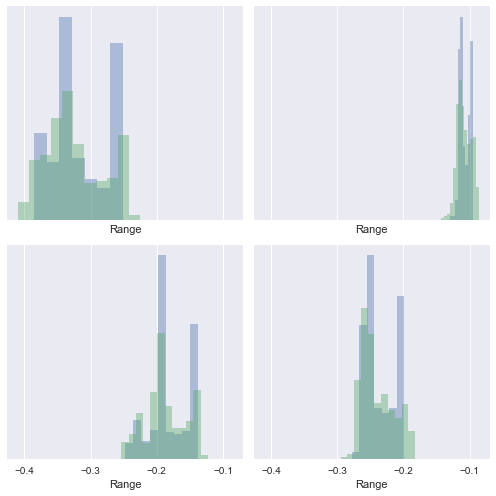

```python
dist_plotv2(c1_2y3y5y,c1_3y4y5y,c1_2y3y4y,c1_2y4y5y)
```

##### Signal 2 Distrubution Plots

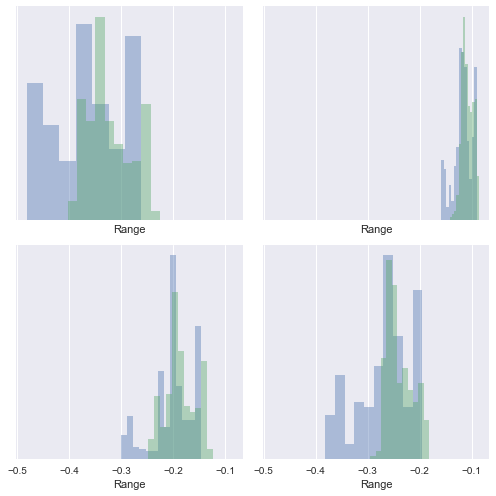

```python
dist_plotv2(c2_2y3y5y,c2_3y4y5y,c2_2y3y4y,c2_2y4y5y)
```

##### Signal 3 Distrubution Plots

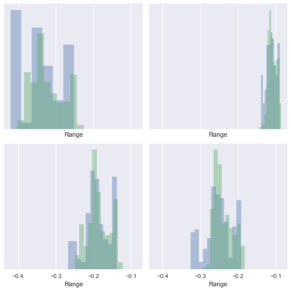

```python
dist_plotv2(c3_2y3y5y,c3_3y4y5y,c3_2y3y4y,c3_2y4y5y)
```

##### Signal 4 Distrubution Plots

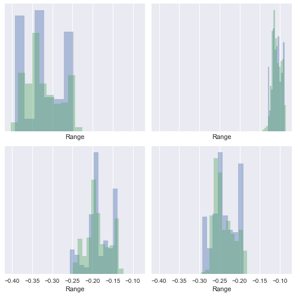

```python
dist_plotv2(s4_c1.s4,s4_c2.s4,s4_c3.s4,s4_c4.s4)
```

```python
#Signal 1

# Butterfly 1: [2y,3y,5y] for last year of sample C
df_pre=c1_2y3y5y.predicted[:-10]
df_real=c1_2y3y5y.realized[:-10]
print('\033[1m'+"Results for Signal 1 and Butterfly 1 (predicted): [2y,3y,5y] "+'\033[0m')
half_life(df_pre)
print()
ADF(df_pre)
print()
Hurst_exponent(df_pre)
print()
print('\033[1m'+"Results for Signal 1 and Butterfly 1 (realized): [2y,3y,5y] "+'\033[0m')
half_life(df_real)
print()
ADF(df_real)
print()
Hurst_exponent(df_real)

print()

# Butterfly 2: [3y,4y,5y] for last year of sample C
df_pre=c1_3y4y5y.predicted[:-10]
df_real=c1_3y4y5y.realized[:-10]
print('\033[1m'+"Results for Signal 1 and Butterfly 2 (predicted): [3y,4y,5y] "+'\033[0m')
half_life(df_pre)
print()
ADF(df_pre)
print()
Hurst_exponent(df_pre)
print()
print('\033[1m'+"Results for Signal 1 and Butterfly 2 (realized): [3y,4y,5y] "+'\033[0m')
half_life(df_real)
print()
ADF(df_real)
print()
Hurst_exponent(df_real)

print()


# Butterfly 3: [2y,3y,4y] for last year of sample C
df_pre=c1_2y3y4y.predicted[:-10]
df_real=c1_2y3y4y.realized[:-10]
print('\033[1m'+"Results for Signal 1 and Butterfly 3 (predicted): [2y,3y,4y] "+'\033[0m')
half_life(df_pre)
print()
ADF(df_pre)
print()
Hurst_exponent(df_pre)
print()
print('\033[1m'+"Results for Signal 1 and Butterfly 3 (realized): [2y,3y,4y] "+'\033[0m')
half_life(df_real)
print()
ADF(df_real)
print()
Hurst_exponent(df_real)

print()

# Butterfly 4: [2y,4y,5y] for last year of sample C
df_pre=c1_2y4y5y.predicted[:-10]
df_real=c1_2y4y5y.realized[:-10]
print('\033[1m'+"Results for Signal 1 and Butterfly 4 (predicted): [2y,4y,5y] "+'\033[0m')
half_life(df_pre)
print()
ADF(df_pre)
print()
Hurst_exponent(df_pre)
print()
print('\033[1m'+"Results for Signal 1 and Butterfly 4 (realized): [2y,4y,5y] "+'\033[0m')
half_life(df_real)
print()
ADF(df_real)
print()
Hurst_exponent(df_real)
```

```
Results for Signal 1 and Butterfly 1 (predicted): [2y,3y,5y]
Half-Life: 320.95005112108265
Beta: -0.0021596730648235554

ADF Statistic: -0.680238
p-value: 0.851802
Critical Values:
	1%: -3.449
	5%: -2.870
	10%: -2.571

Hurst Exponent: 0.6523140966713341

Results for Signal 1 and Butterfly 1 (realized): [2y,3y,5y]
Half-Life: 59.30895051097039
Beta: -0.011687058607313136

ADF Statistic: -1.006469
p-value: 0.750898
Critical Values:
	1%: -3.449
	5%: -2.870
	10%: -2.571

Hurst Exponent: 0.5887298373915827

Results for Signal 1 and Butterfly 2 (predicted): [3y,4y,5y]
Half-Life: 37.82414510877493
Beta: -0.018325521398212384

ADF Statistic: -1.481144
p-value: 0.542817
Critical Values:
	1%: -3.449
	5%: -2.870
	10%: -2.571

Hurst Exponent: 0.5199293092064423

Results for Signal 1 and Butterfly 2 (realized): [3y,4y,5y]
```

[output cut: 48 more lines]

```

Hurst Exponent: 0.575368048665811

Results for Signal 1 and Butterfly 4 (realized): [2y,4y,5y]
Half-Life: 20.485437307359273
Beta: -0.033836093911987726

ADF Statistic: -2.155815
p-value: 0.222671
Critical Values:
	1%: -3.449
	5%: -2.870
	10%: -2.571

Hurst Exponent: 0.4828276167312155
```

### Similar mean-reversion test can be done for other found signals as well , such as we saw in the sample B example.

### All of the comparisons, results & discussion can be observed within this report (code) in the parts above under Sample (A,B,C) evaluations.